# Patient Treatment Timelines for Longitudinal Survival Data

Katherine Hoffman

2019-11-28T21:13:14-05:00

I am a biostatistician at a research university, and I often find myself working with longitudinal survival data. As with any data analysis, I need to examine the quality of my data before deciding which statistical methods I will be able to implement.

This post contains reproducible examples for how I prefer to visually explore survival data containing longitudinal exposures or covariates. I create a “treatment timeline” for each patient, and the end product looks something like this:

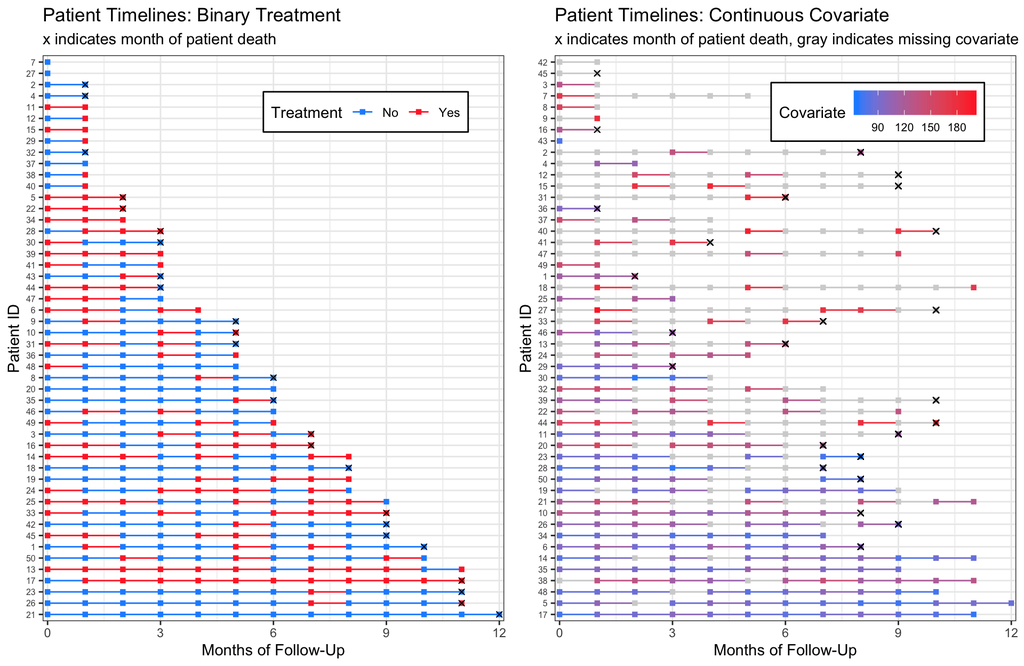

Each line represents one patient, and each square represents a measurement at a specified point. I find these graphs useful to look for patterns or discrepancies in follow up times, treatment patterns, and missingness. They also allow me to verify that my coding is correct as I move through different data manipulations for my analyses.

For the following examples I generate longitudinal survival data sets. I skip over how I made this data because it’s not the focus of this post, but if you have questions about the data generation please let me know. In general, I am trying to work from the point in a survival data analysis where you’ve already calculated each individual’s time to event.

# Example 1: Binary Treatment

To make these charts, my first step is to load the package `tidyverse`, since I use functions from `dplyr`, `tidyr`, `forcats`, and `ggplot2`.

```r
library(tidyverse)
```

Here is the data generation code. If you’re interested in how I made it, you can check the comments, but if not, **I recommend just copying and pasting into your `R` console to try the plotting code!**

```r
set.seed(7)
n <- 50 # The data sets I make these visualizations for are typically 100-500 patients in size, but for space purposes I'll set my n to only 50.
dat <-
  tibble(.rows = n) %>%  # empty data frame / tibble with n rows
  mutate(pt_id = factor(row_number()),  # patient ids are 1-n
         pt_trt_prob = runif(n,0,1), # randomly generate a treatment probability for each patient so we can see patterns
         months_followup = round(runif(n, 0, 20) + 3 * pt_trt_prob), # randomly generate length of time in the study, which is affected by the prob of treatment
         death = rbinom(n, 1, .5)) %>% # death is not affected by treatment and randomly occurs at any time point. Obviously an unrealistic assumption. :)
  group_by(pt_id) %>%   # group by patient so we can do more data manipulation
  complete(months_followup = full_seq(0:max(months_followup), 1)) %>% # add in all the months patients are in the study
  fill(pt_trt_prob, .direction = "up") %>% # fill in the treatment probability I made earlier so I can use this to add treatment for every time point
  ungroup() %>% # no longer need patients grouped
  mutate(trt = factor(rbinom(row_number(), 1, pt_trt_prob^2)),  # fill in treatment for everyone based on their treatment probability
         death = replace_na(death, 0)) %>%  # also fill in death
  select(pt_id, months_followup, trt, death) # remove leftover columns from data generation
```

Let’s look at the data. It’s in “long” format with patient ID’s repeating for each `month_followup` they were in my (fake) study. At every month, we know whether or not they were on the treatment, and whether they died at that time point. This first example does not contain any missingness.

```r
dat %>% filter(pt_id == 5) %>% knitr::kable()
```

| pt_id | months_followup | trt | death |
| --- | --- | --- | --- |
| 5 | 0 | 0 | 0 |
| 5 | 1 | 0 | 0 |
| 5 | 2 | 0 | 0 |
| 5 | 3 | 0 | 0 |
| 5 | 4 | 0 | 0 |
| 5 | 5 | 0 | 0 |
| 5 | 6 | 0 | 0 |
| 5 | 7 | 0 | 0 |
| 5 | 8 | 0 | 0 |
| 5 | 9 | 0 | 0 |
| 5 | 10 | 0 | 0 |
| 5 | 11 | 0 | 0 |
| 5 | 12 | 0 | 0 |
| 5 | 13 | 0 | 0 |
| 5 | 14 | 0 | 0 |
| 5 | 15 | 0 | 1 |

We can now plot our data in a very basic way. We really only need to specify in the `aes`thetics that the `x`-axis is time, the `y`-axis is subject IDs, the `col`or should correspond to treatment, and *our lines should be `group`ed together by subject*. Don’t forget that last one! Then we can say we want `geom_line` to make a base timeline for each subject, and the points on the timeline should be squares (`shape = 15` in the `geom_point` mapping function).

Et voilà! A cute patient treatment timeline.

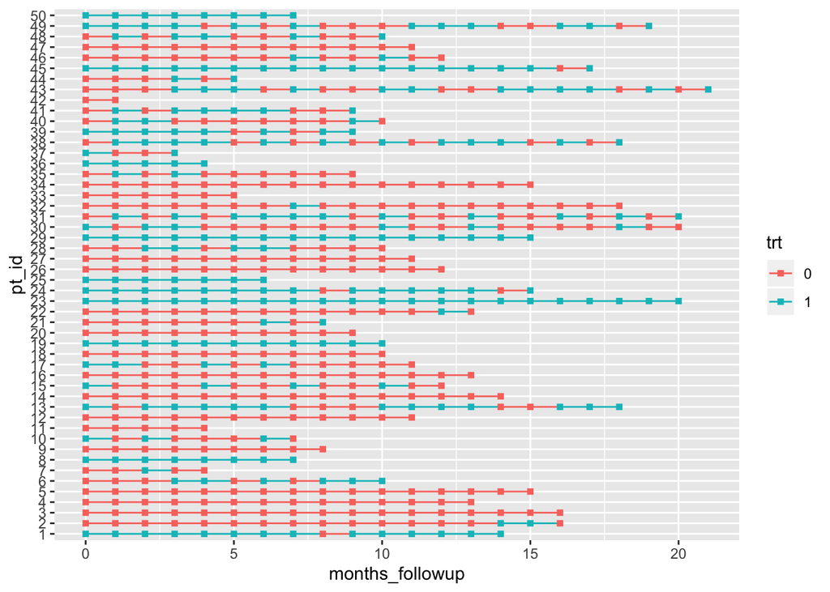

```r
dat %>%
  ggplot(aes(x = months_followup, y = pt_id, group = pt_id, col = trt)) +
  geom_line()  +
  geom_point(shape = 15)
```

Okay, it’s not *that* cute. But that little bit of code is really the core of the plot! If you want to add markers of death (or any other event) and rearrange by length of follow up time it just takes a little bit of extra data manipulation and one additional line of `ggplot2` code.

```
## Warning: Removed 594 rows containing missing values (geom_point).
```

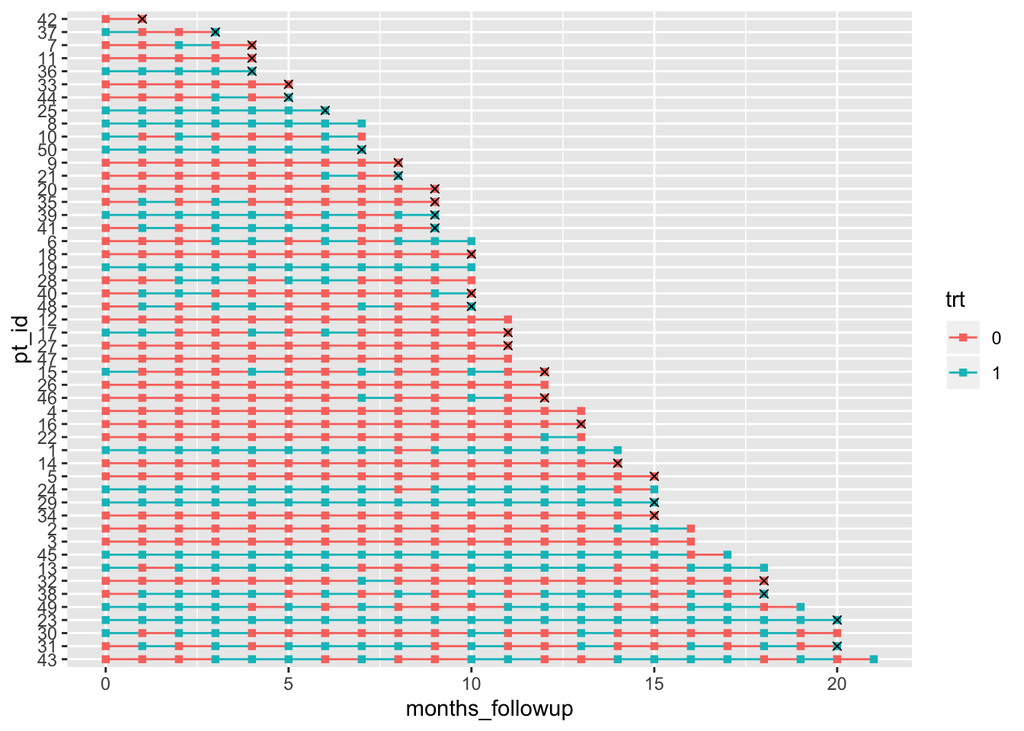

```r
dat %>%
  group_by(pt_id) %>%
  # make a new column with all patients last follow up visit
  mutate(last_month_followup = max(months_followup),
         # new variable for month that patients died, if they died
         month_death = case_when(death == 1 ~ last_month_followup, TRUE ~ NA_real_)) %>%
         # reorder pt id by last month of follow up (highest to lowest)
         # without fct_rev, chart is arranged in opposite direction (lowest to highest)
  ungroup() %>%
  mutate(pt_id = fct_rev(fct_reorder(pt_id, last_month_followup))) %>%
  ggplot(aes(x = months_followup, y = pt_id, group = pt_id, col = trt)) +
  geom_line()  +
  geom_point(shape = 15) +
  # add in a new mapping layer of points that correspond to death
  geom_point(aes(x = month_death, y = pt_id), col = "black", shape = 4)
```

Don’t worry about the warning for removing missing values – it’s because we have `NA`s at most months for our `month_death`, so `geom_point` doesn’t know where to put an ‘x’ marker.

Finally, let’s work on making the plot a bit nicer to look at:

```
## Warning: Removed 594 rows containing missing values (geom_point).
```

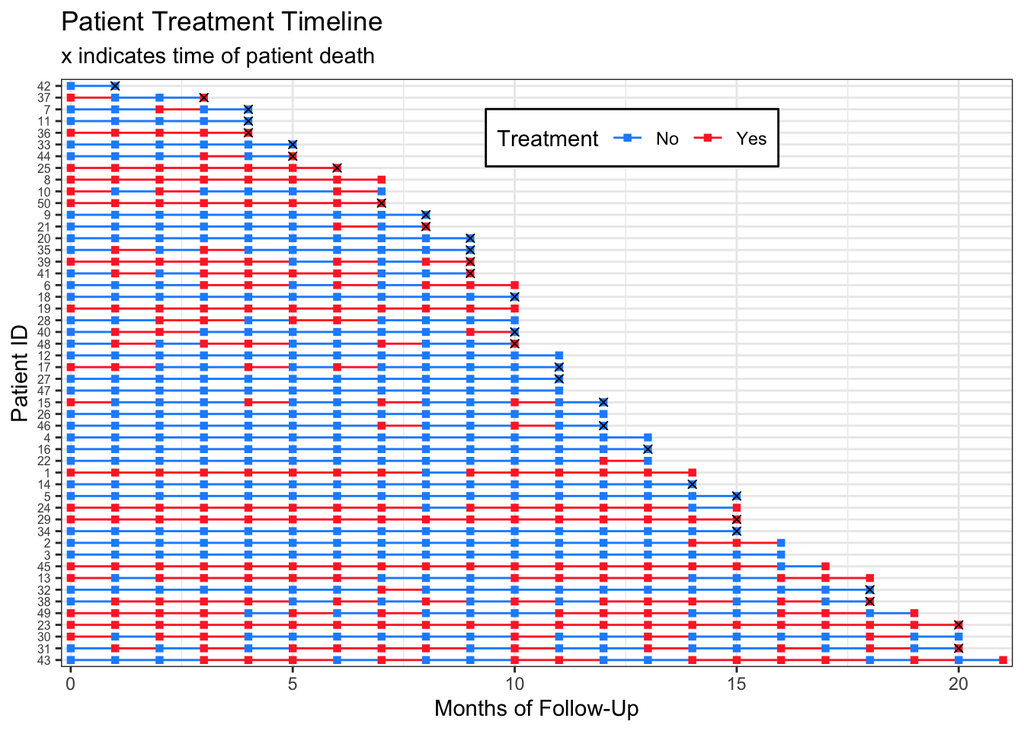

```r
dat %>%
  group_by(pt_id) %>%
  mutate(last_month_followup = max(months_followup),
         month_death = case_when(death == 1 ~ last_month_followup, TRUE ~ NA_real_)) %>%
  ungroup() %>%
  mutate(pt_id = fct_rev(fct_reorder(pt_id, last_month_followup)),
         # make the treatment variable labels nicer
         trt = factor(trt, levels=0:1, labels=c("No","Yes"))) %>%
  ggplot(aes(x = months_followup, y = pt_id, group = pt_id, col = trt)) +
  geom_line()  +
  geom_point(shape = 15) +
  geom_point(aes(x = month_death, y = pt_id), col = "black", shape = 4) +
  theme_bw() +
  labs(x = "Months of Follow-Up", y = "Patient ID", col = "Treatment",
       title = "Patient Treatment Timeline",
       subtitle = "x indicates time of patient death") +
  # edit legend box and make patient ids small
  theme(axis.text.y = element_text(size=6),
        legend.position = c(.6, .9), legend.direction = "horizontal",
        legend.background = element_rect(linetype="solid", colour ="black")) +
  # remove extra space around timeline
  scale_x_continuous(expand=c(0.01,0.01)) +
  # set the color of the lines and points
  scale_color_manual(values=c("dodgerblue","firebrick1"))
```

I have never made one of these plots for publication, so I don’t mind that the subtitle contains legend information. If you wanted to have the `month_death` markers in a legend, you could change:

```r
geom_point(aes(x = month_death, y = pt_id), col = "black", shape = 4)
```

to:

```r
geom_point(aes(x = month_death, y = pt_id, shape = month_death), col = "black")
```

# Example 2: Continuous Covariate with Missingness

We can follow the very same steps for making a timeline for a continuous variable.

Again, here is the data generation code:

```r
dat_cc <-
  tibble(.rows = n) %>%
  mutate(pt_id = row_number(),
         months_followup = round(runif(n, 0, 12)),
         pt_cov_mean = runif(n, 80, 150),
         death = rbinom(n, 1, 0.5)) %>%
  group_by(pt_id) %>%
  complete(months_followup = full_seq(0:max(months_followup), 1)) %>%
  fill(pt_cov_mean, death, .direction = "up") %>%
  mutate(last_month_followup = max(months_followup),
         death_date = case_when(death == 1 ~ last_month_followup, TRUE ~ NA_real_)) %>%
  ungroup() %>%
  mutate(cov = rnorm(row_number(), pt_cov_mean, 10))
```

```r
dat_cc_samp <- dat_cc %>%
  mutate(idx = row_number()) %>%
  sample_frac(.5, weight = pt_cov_mean^3)  %>% # sample 50% of data, with weights for the sample determined by the patient's mean covariate. This would mean patients with a higher covariate are more likely to have missing data. Perhaps they are sicker patients!
  pull(idx)

dat_cc_miss  <- dat_cc %>%
  mutate(cov = case_when(row_number() %in% dat_cc_samp ~ NA_real_,
                         TRUE ~ cov)) %>%
  select(pt_id, months_followup, cov, death)
```

Looking again at the data we’ll be using:

```r
knitr::kable(head(dat_cc_miss))
```

| pt_id | months_followup | cov | death |
| --- | --- | --- | --- |
| 1 | 0 | NA | 1 |
| 1 | 1 | NA | 1 |
| 1 | 2 | 126.0648 | 1 |
| 2 | 0 | NA | 1 |
| 2 | 1 | NA | 1 |
| 2 | 2 | NA | 1 |

We can plot the data and see this missingness with gray timeline points and lines:

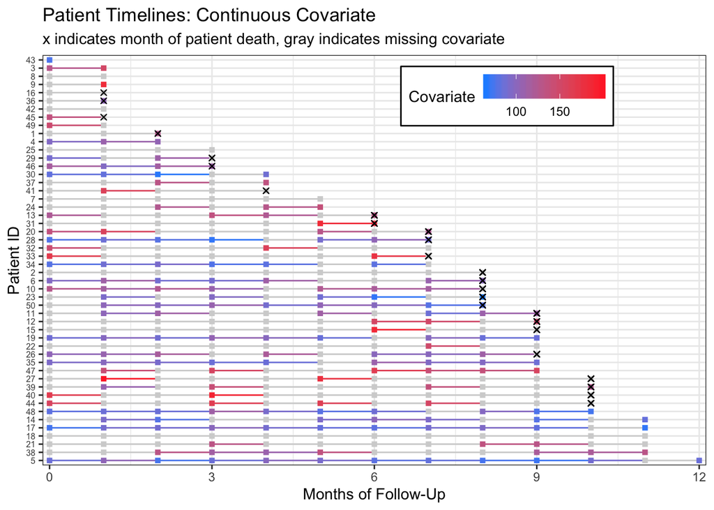

```r
dat_cc_miss %>%
  group_by(pt_id) %>%
  mutate(last_month_followup = max(months_followup),
         month_death = case_when(death == 1 ~ last_month_followup, TRUE ~ NA_real_)) %>%
  ungroup() %>%
  mutate(pt_id = fct_rev(fct_reorder(factor(pt_id), last_month_followup))) %>%
  ggplot(aes(x = months_followup, y = pt_id,
             group = pt_id, col = cov)) +
  geom_line()  +
  geom_point(shape = 15) +
  geom_point(aes(x = month_death, y = pt_id), shape=4, col="black") +
  theme_bw() +
  labs(x = "Months of Follow-Up", y = "Patient ID", col = "Covariate",
       title = "Patient Timelines: Continuous Covariate",
       subtitle = "x indicates month of patient death, gray indicates missing covariate") +
  theme(axis.text.y = element_text(size=6),
        legend.position = c(.7, .9),
        legend.direction = "horizontal",
        legend.background = element_rect(linetype="solid", colour ="black")) +
  scale_x_continuous(expand=c(0.01,0.01)) +
  scale_color_gradient(low="dodgerblue", high="firebrick1", na.value = "lightgray")
```

Alternatively, we could rearrange our timelines by the number of measures we have for each patients `cov`ariate of interest by making a new column containing the `sum(!is.na(cov))` and rearranging our `pt_id` by that column.

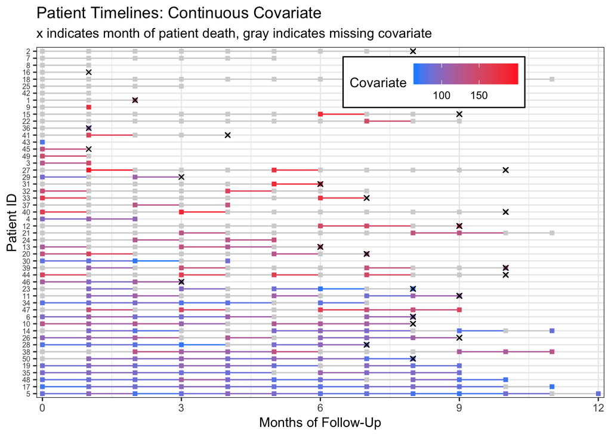

```r
dat_cc_miss %>%
  group_by(pt_id) %>%
  mutate(last_month_followup = max(months_followup),
         # a column containing how many measures we have for each patient
         n_measures = sum(!is.na(cov))) %>%
  ungroup() %>%
  mutate(
    # reorder IDs by number of measures we have for each patient
    pt_id = fct_rev(fct_reorder(factor(pt_id), n_measures)),
  month_death = case_when(death == 1 ~ last_month_followup, TRUE ~ NA_real_)) %>%
  ggplot(aes(x = months_followup, y = pt_id,
             group = pt_id, col = cov)) +
  geom_line()  +
  geom_point(shape = 15) +
  geom_point(aes(x = month_death, y = pt_id), shape=4, col="black") +
  theme_bw() +
  labs(x = "Months of Follow-Up", y = "Patient ID", col = "Covariate",
       title = "Patient Timelines: Continuous Covariate",
       subtitle = "x indicates month of patient death, gray indicates missing covariate") +
  theme(axis.text.y = element_text(size=6),
        legend.position = c(.7, .9),
        legend.direction = "horizontal",
        legend.background = element_rect(linetype="solid", colour ="black")) +
  scale_x_continuous(expand=c(0.01,0.01)) +
  scale_color_gradient(low="dodgerblue",high="firebrick1",na.value = "lightgray")
```

From this plot we can start to see that patients with less missing measurements measurements look like they have longer lengths of follow up and lower covariate measurements. If this were my real data, I would follow up with my research collaborators for more information on this missingness pattern.

Please let me know if you have questions or a suggestion for a data set. Happy treatment timeline plotting!